# Taller ecuaciones lineales

Nicolás Camacho Plazas  
Daniela Cortes Antonio  
Mateo Florido Sanchez

### Primer punto

Para el siguiente ejercico, instale el paquete “pracma”  
a. Revise las siguientes funciones con la matriz del ejercicio 2  
b. Evalue la matriz de transición para el método $\textbf{SOR}$

```r
library(pracma)
library(Matrix)
library(BB)
require(grid)
#require(plotrix)
diagMatriz=function(A){
  A[col(A)!=row(A)]<-0
  return(A)
}

A = matrix(c(-8.1, -7, 6.123, -2, -1, 4,-3, -1, 0, -1, -5, 0.6,-1, 0.33, 6, 1/2), nrow=4, byrow=TRUE)
eye(3)
```

```
     [,1] [,2] [,3]
[1,]    1    0    0
[2,]    0    1    0
[3,]    0    0    1
```

```r
ones(3)
```

```
     [,1] [,2] [,3]
[1,]    1    1    1
[2,]    1    1    1
[3,]    1    1    1
```

```r
zeros(3)
```

```
     [,1] [,2] [,3]
[1,]    0    0    0
[2,]    0    0    0
[3,]    0    0    0
```

```r
#Literal b
w=1
D=diag(A)
L=tril(A)
U=triu(A)
T=((-solve((D-w*L)))*(((1-w)*D)+(w*U)))
cat("  b): para w=1\n")
```

```
  b): para w=1
```

```r
print(T)
```

```
         [,1]       [,2]       [,3]       [,4]
[1,] 1.753368 -0.9212435  2.7918342 -0.8290155
[2,] 0.000000  1.6580311 -1.7098446 -0.5181347
[3,] 0.000000  0.0000000 -0.7098446  0.1865285
[4,] 0.000000  0.0000000  0.0000000 -0.4145078
```

### Segundo punto

Dada la siguiente matriz, utilice las funciones del paquete para descomponer la matriz $A=L+D+U$ (Jacobi)

```
     [,1]  [,2]   [,3] [,4]
[1,] -8.1 -7.00  6.123 -2.0
[2,] -1.0  4.00 -3.000 -1.0
[3,]  0.0 -1.00 -5.000  0.6
[4,] -1.0  0.33  6.000  0.5
```

2. Utilice la función itersolve(A, b, tol , method = “Gauss-Seidel”) y solucionar el sistema asociado a la matriz $A$ con $b=[1.45,3,5.12,-4]^{t}$ con una tolerancia de $1e^-9$
3. Genere 5 iteraciones del método de Jacobi, calcular error relativo para cada iteracion

```r
#Segundo punto
#Literal b

B=matrix(c(1.45,3,5.12,-4), nrow=4, byrow=TRUE)
X=itersolve(A,B,tol=1e-9,method = "Gauss-Seidel")
print(X)
```

```
$x
[1] -3.696138e+196  2.853479e+196  1.611118e+196
[4] -2.860899e+197

$iter
[1] 1000

$method
[1] "Gauss-Seidel"
```

```r
#Literal c

x0=c(1,1,1,1)
for(i in 1:5){
  xk<-itersolve(A,B,x0,nmax=i,method="Jacobi")
  xk_1<-itersolve(A,B,x0,nmax=1+i,method="Jacobi")
  Err=xk_1[[1]]-xk[[1]]
  cat("Error relativo en la iteración #",i," es de: ",Err,"\n")
}
```

```
Error relativo en la iteración # 1  es de:  2.399655 -6.876549 -2.5592 21.5196
Error relativo en la iteración # 2  es de:  -1.305351 4.060415 3.957662 40.04823
Error relativo en la iteración # 3  es de:  -10.40575 12.65397 3.993705 -52.78253
Error relativo en la iteración # 4  es de:  5.11614 -12.80179 -8.864697 -77.08759
Error relativo en la iteración # 5  es de:  23.39619 -24.64138 -6.690152 125.0578
```

### Tercer punto A.

Sea el sistema $AX=b$  
a. Implemente una función en R para que evalue las raíces del polinomio característico asociado a la matriz $A$  
b. Use el teorema de convergencia para determinar cuál método iterativo es más favorable.  
c. Evalue la matriz de transición para cada caso y en el caso del método de relajación determine el valor séptimo de $\omega$  
d. Teniendo en cuenta lo anterio resolver el sistema

```r
#Tercer punto
#Literal a (se utiliza el m?todo del paquete pracma llamado charpoly)

PolCarct=charpoly(A, info=FALSE)
print(PolCarct)
```

```
[1]    1.0000    8.6000  -31.7200 -224.3022  320.0681
```

```r
#Literal b
cat("De acuerdo al teorema de convergencia, el método mas
    eficiente y rápido es el de Gauss-Seidel en el caso en el que la matriz
    sea diagonalmente dominante.Los dos métodos convergen si la matriz es diagonalmente dominante y si es simetrica
    definida positiva \n")
```

```
De acuerdo al teorema de convergencia, el método mas
    eficiente y rápido es el de Gauss-Seidel en el caso en el que la matriz
    sea diagonalmente dominante.Los dos métodos convergen si la matriz es diagonalmente dominante y si es simetrica
    definida positiva
```

```r
#Literal c
w=1
D=diag(A)
L=tril(A)
U=triu(A)
T1=((-solve((D-w*L)))*(((1-w)*D)+(w*U)))
T2=(-solve(A))%*%U+diagMatriz(A)+L%*%(-solve(A))
T3=-solve(A)%*%(L+U)
cat("Transicion en relajación :\n")
```

```
Transicion en relajación :
```

```r
print(T1)
```

```
         [,1]       [,2]       [,3]       [,4]
[1,] 1.753368 -0.9212435  2.7918342 -0.8290155
[2,] 0.000000  1.6580311 -1.7098446 -0.5181347
[3,] 0.000000  0.0000000 -0.7098446  0.1865285
[4,] 0.000000  0.0000000  0.0000000 -0.4145078
```

```r
cat("Para que w sea óptimo, debe estar entre en el intervalo [0,2]\n")
```

```
Para que w sea óptimo, debe estar entre en el intervalo [0,2]
```

```r
cat("Transición en Gauss Siedel: \n")
```

```
Transición en Gauss Siedel:
```

```r
print(T2)
```

```
            [,1]       [,2]       [,3]       [,4]
[1,] -9.22080164 -1.1974666 -4.0170025 -2.1518086
[2,] -0.23443139  2.1508200  0.4990008 -0.8749483
[3,] -0.06903594  0.1217504 -6.2157651  0.4263275
[4,] -0.69214968 -0.5245697  4.2632746 -1.5000000
```

```r
cat("Transición en Jacobi: \n")
```

```
Transición en Jacobi:
```

```r
print(T3)
```

```
           [,1]        [,2]       [,3]        [,4]
[1,] -1.5604008  0.69577521 -1.4957224  0.13282769
[2,] -0.3264618 -1.69655436  0.1447427 -0.07616162
[3,] -0.0177656  0.14814100 -1.5735187 -0.02740042
[4,] -0.6921497  0.07358435  3.7952490 -1.35527288
```

4. Comparar con la solución por defecto

```r
A = matrix(c(4, -1, -1, -1, -1, 4,-1, -1, -1, -1, 4, -1,-1, -1, -1, 4), nrow=4, byrow=TRUE)
B = c(1, 5, 1.5,-2.33)
print(A)
```

```
     [,1] [,2] [,3] [,4]
[1,]    4   -1   -1   -1
[2,]   -1    4   -1   -1
[3,]   -1   -1    4   -1
[4,]   -1   -1   -1    4
```

```r
cat("De acuerdo a el teorema de convergencia, Gauss-Seidel es mas rápido cuando la matriz es diagonalmente dominante.Como la diagonal principal esta conformada por 4 y el resto es -1, en cada ecuaciín existira la desigualdad: 4>3, por lo tanto, es una matriz diagonalmente dominante. \n")
```

```
De acuerdo a el teorema de convergencia, Gauss-Seidel es mas rápido cuando la matriz es diagonalmente dominante.Como la diagonal principal esta conformada por 4 y el resto es -1, en cada ecuaciín existira la desigualdad: 4>3, por lo tanto, es una matriz diagonalmente dominante.
```

```r
X=itersolve(A,B,method = "Gauss-Seidel")
print(X)
```

```
$x
[1] 1.234 2.034 1.334 0.568

$iter
[1] 31

$method
[1] "Gauss-Seidel"
```

```r
solucion<-solve(A,B)
print(solucion)
```

```
[1] 1.234 2.034 1.334 0.568
```

### Tercer punto B.

1. Pruebe el siguiente algoritmo con una matriz $A_{3}$, modifiquelo para quue $a_{ii}=0$ para todo $i$

```r
tril1 <- function(M, k = 0) {

  M[col(M)==row(M)] <- 0

  return(M)
}
M = matrix(c(0,3,2,
             5,0,8,
             1,3,0), nrow=3, byrow=TRUE)
tril1(M)
```

```
     [,1] [,2] [,3]
[1,]    0    3    2
[2,]    5    0    8
[3,]    1    3    0
```

2. Implemente una función en R para que dada una matriz $A$ se obtenga una matriz diagonal $D$ donde en la diagonal estan los mismo elementos de A

```r
FoundD<- function(M, k = 0) {

  M[col(M)!=row(M)] <- 0
  return(M)
}
M = matrix(c(1,3,2,
             5,8,8,
             1,3,2), nrow=3, byrow=TRUE)
FoundD(M)
```

```
     [,1] [,2] [,3]
[1,]    1    0    0
[2,]    0    8    0
[3,]    0    0    2
```

### Cuarto punto

Cree una función que cuente el número de multiplicaciones en el método directo de Gauss Jordan, para resolver un sistema de $n$ ecuaciones y pruebelo para $n=5$

```r
gaussPP = function(C)
{

  cantprod=0 #Inicializamos el contador de productos en 0
  for (j in 1:(nrow(C))) #Un for que recorra todas las filas.
  {
    #wich.max( A[j:n,j] ) retorna Ã?ndice del vector A[j:n,j] = (a_jj, a_(j+1)j,...,a_nj)
    # Como a_jj tendrÃ?a Ã?ndice 1, hay que corregir el Ã?ndice sumando j-1.

    if(j < nrow(C)){ #Mientras que este no este en la fila de coeficientes de B:
      row= which.max( abs(C[j:nrow(C),j]) ) #Obtenemos el mayor indice del todas las filas de una misma columna.
      row=row-1
      C[c(j, row+j), ] = C[c(row+j, j), ]

      for (k in (j+1):nrow(C)) #Mientras que estemos debajo de la diagonal
      {
        cantprod = cantprod + 1 #Aumenta en uno la cantidad de productos
        C[k, ] = C[k, ] - C[k, j]/C[j,j]*C[j, ] # Modificamos la fila
      }
    }
    for(i in (j):1)
    {
      cantprod = cantprod + 1  #Aumenta en uno la cantidad de productos

      if(i != j)  #Mientras que no estemos en la diagonal, le restamos a la fila actual el valor del pivote dividido en la fila que se elimino anteriormente
        C[i, ] = C[i, ] - C[i,j]*C[j,]
      else
        C[i, ] = C[i, ]/C[i,j] #Dividimos por el valor del pivote.
    }
  }

  cat("Solución:\n")
  print(C)
  return(cantprod)
}
A = matrix(c( 2, 3, 5, 6, 1,
              4,5,6,1/2,5,
              5,3,10,2,3,
              8,6,4,2,1/2,
              3,7,10,2,15), nrow=5, byrow=TRUE)
B = c(1,2,3,4,5)
if(nrow(A)!=ncol(A) ){
  stop("La matriz no es cuadrada, no se puede realizar el método Gauss")
}
AB = cbind(A,B)
print(AB)
```

```
                     B
[1,] 2 3  5 6.0  1.0 1
[2,] 4 5  6 0.5  5.0 2
[3,] 5 3 10 2.0  3.0 3
[4,] 8 6  4 2.0  0.5 4
[5,] 3 7 10 2.0 15.0 5
```

```r
cat("Número de productos que realiza Gauss: " , gaussPP(AB))
```

```
Solución:
                        B
[1,] 1 0 0 0 0  1.1892640
[2,] 0 1 0 0 0 -0.8949640
[3,] 0 0 1 0 0 -0.2958495
[4,] 0 0 0 1 0  0.3537355
[5,] 0 0 0 0 1  0.6631987
Número de productos que realiza Gauss:  25
```

### Quinto punto

Dado el siguiente sistema:

```
$2x-z=1$
$\beta$x+2y-z=2
$-x+y+$\alpha$z=1$
```

1. Encuentre el valor de $\alpha$ y $\beta$ para asegura la convergencia por el método de Jacobi
2. Genere una tabla que tenga 10 iteraciones del método de Jacobi con vector inicial $x_{0}=[1,2,3]^t$
3. Grafique cada ecuación y la soñlución

```r
SolveAB <- function(M) {
  M[2,1] = M[2,2]- abs(M[2,3])-1
  M[3,3] = abs(M[3,1])+abs(M[3,2])+1
  return(M)
}

A = matrix(c(2, 0, 1,
             0,2 , -1,
             -1, 1, 0), nrow=3, byrow=TRUE)
B = matrix (c(1,2,1),nrow=3, byrow=TRUE)
A<-SolveAB(A)
Ab = cbind(A,B)
print(Ab)
```

```
     [,1] [,2] [,3] [,4]
[1,]    2    0    1    1
[2,]    0    2   -1    2
[3,]   -1    1    3    1
```

```r
x0=c(1,2,3)
print(Ab)
```

```
     [,1] [,2] [,3] [,4]
[1,]    2    0    1    1
[2,]    0    2   -1    2
[3,]   -1    1    3    1
```

```r
for(i in 1:10){

  sol<-itersolve(A,B,x0,nmax=i,method="Jacobi")
  cat("Iteración # ", i ,"\n")
  F <- matrix (c (sol$x), nrow=3,byrow=TRUE)
  print(F)
}
```

```
Iteración #  1
     [,1]
[1,] -1.0
[2,]  2.5
[3,]  0.0
Iteración #  2
           [,1]
[1,]  0.5000000
[2,]  1.0000000
[3,] -0.8333333
Iteración #  3
          [,1]
[1,] 0.9166667
[2,] 0.5833333
[3,] 0.1666667
Iteración #  4
          [,1]
[1,] 0.4166667
[2,] 1.0833333
[3,] 0.4444444
Iteración #  5
          [,1]
[1,] 0.2777778
[2,] 1.2222222
[3,] 0.1111111
Iteración #  6
           [,1]
[1,] 0.44444444
[2,] 1.05555556
[3,] 0.01851852
Iteración #  7
          [,1]
[1,] 0.4907407
[2,] 1.0092593
[3,] 0.1296296
Iteración #  8
          [,1]
[1,] 0.4351852
[2,] 1.0648148
[3,] 0.1604938
Iteración #  9
          [,1]
[1,] 0.4197531
[2,] 1.0802469
[3,] 0.1234568
Iteración #  10
          [,1]
[1,] 0.4382716
[2,] 1.0617284
[3,] 0.1131687
```

```r
#install.packages("rgl")
#library("rgl")
#require("rgl")
# Grafique cada ecuación y la solución

#open3d()
#x <- (1+z)/2
#y <- 1-2*x
#z <- rnorm(100)
#a<-(c())
#fit <- lm(z ~ x + y)
#p1<-planes3d(0, 2, -1, 2, alpha = 10, col="blue")
#p3<-planes3d(2, 0, 1, 1, alpha = 10,col="red")
#p2<-planes3d(-1, 1, 0, 1, alpha = 10, col="yellow")
#plot3d(x, y, z, type = "s", col = "white", size = 0,add=p2+p1+p3)
#decorate3d(axes=TRUE,box=TRUE)
#aspect3d(1,1,1)
```

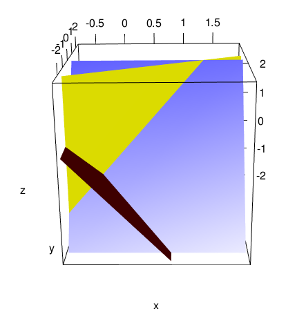

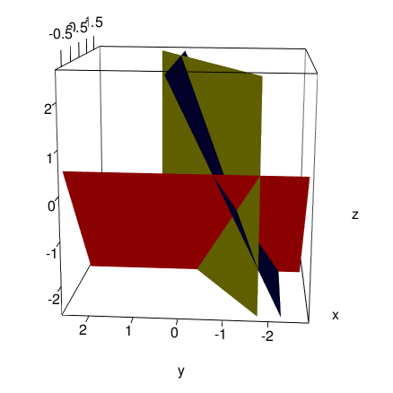

### Sexto punto

Instalar el paquete Matrix y descomponga la matriz $A$ (del punto dos) de la forma $LU$ y la factorizarla como $A=QR$

```r
#Punto 6
A = matrix(c(-8.1, -7, 6.123, -2, -1, 4,
             -3, -1, 0, -1, -5, 0.6,
             -1, 0.33, 6, 1/2), nrow=4, byrow=TRUE)
print(A)
```

```
     [,1]  [,2]   [,3] [,4]
[1,] -8.1 -7.00  6.123 -2.0
[2,] -1.0  4.00 -3.000 -1.0
[3,]  0.0 -1.00 -5.000  0.6
[4,] -1.0  0.33  6.000  0.5
```

```r
b = matrix(c(1.45,3,5.12,-4), nrow=4, byrow=TRUE)

L = tril(A,k=-1)
U = triu(A,k=1)
print(L)
```

```
     [,1]  [,2] [,3] [,4]
[1,]    0  0.00    0    0
[2,]   -1  0.00    0    0
[3,]    0 -1.00    0    0
[4,]   -1  0.33    6    0
```

```r
print(U)
```

```
     [,1] [,2]   [,3] [,4]
[1,]    0   -7  6.123 -2.0
[2,]    0    0 -3.000 -1.0
[3,]    0    0  0.000  0.6
[4,]    0    0  0.000  0.0
```

```r
AG = gramSchmidt(A)
print(AG)
```

```
$Q
           [,1]       [,2]        [,3]        [,4]
[1,] -0.9850983 -0.1436118 -0.04743408 -0.08189671
[2,] -0.1216171  0.9447015 -0.30403534 -0.01763100
[3,]  0.0000000 -0.1978603 -0.65697987  0.72748111
[4,] -0.1216171  0.2185544  0.68825138  0.68099435

$R
        [,1]     [,2]      [,3]       [,4]
[1,] 8.22253 6.369086 -6.396608  2.0310050
[2,] 0.00000 5.054072 -1.412812 -0.6669168
[3,] 0.00000 0.000000  8.036075  0.3488413
[4,] 0.00000 0.000000  0.000000  0.9584103
```

```r
Q = AG$Q
R = AG$R

print(Q)
```

```
           [,1]       [,2]        [,3]        [,4]
[1,] -0.9850983 -0.1436118 -0.04743408 -0.08189671
[2,] -0.1216171  0.9447015 -0.30403534 -0.01763100
[3,]  0.0000000 -0.1978603 -0.65697987  0.72748111
[4,] -0.1216171  0.2185544  0.68825138  0.68099435
```

```r
print (R)
```

```
        [,1]     [,2]      [,3]       [,4]
[1,] 8.22253 6.369086 -6.396608  2.0310050
[2,] 0.00000 5.054072 -1.412812 -0.6669168
[3,] 0.00000 0.000000  8.036075  0.3488413
[4,] 0.00000 0.000000  0.000000  0.9584103
```

```r
print(Q%*%R)
```

```
     [,1]  [,2]   [,3] [,4]
[1,] -8.1 -7.00  6.123 -2.0
[2,] -1.0  4.00 -3.000 -1.0
[3,]  0.0 -1.00 -5.000  0.6
[4,] -1.0  0.33  6.000  0.5
```

### Séptimo punto

1. Determinar numéricamente la intersección entre la circunferencia $x^2 + y^2 = 1$ y la recta $y = x$. Usamos una aproximación inicial $(1,1)$. Utilice el pauqte BB y la función BBsolve() del paquete,grafique la solución b Analizar y comentar el siguinte código

```r
library(Matrix)
library(pracma)
library(BB)
require(grid)
require(plotrix)
#A
Intersection = function(x)
{
  n = length(x)
  F = rep(NA, n)
  F[ 1 ] = x[ 1 ] - x[ 2 ]
  F[ 2 ] = x[ 1 ]^2 + x[ 2 ]^2 -1
  F
}
Initial = c(1,1)
Solution = BBsolve(par = Initial, fn = Intersection )
```

```
  Successful convergence.
```

```r
cat("Intersección en x: ", Solution$par[ 1 ]," y: ", Solution$par[ 2 ])
```

```
Intersección en x:  0.7071067  y:  0.7071068
```

```r
plot(NULL, xlab = "x", ylab= "y" , main="Figura3. Gráfica solución", xlim = c(-1,1), ylim = c(-1,1))
radius <- 1
theta <- seq(0, 2 * pi, length = 200)
lineEQ <- function(x) x
lines(-1:1,lineEQ(-1:1),type = 'l', new = FALSE, xlim = c(-1,1), ylim = c(-1,1))
```

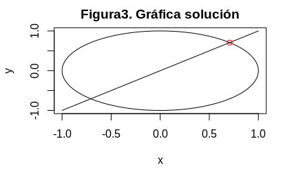

```r
lines(x = radius * cos(theta), y = radius * sin(theta))
lines( Solution$par[ 1 ], Solution$par[ 2 ], type = "p", col = "red")
```

```r
#B
trigexp = function(x)
{
  #Adquiere el n para saber el número de variables que va a contener el sistema
  n = length(x)
  #Creamos a F, el vector que contiene las ecuaciones, con n posiciones vacías
  F = rep(NA, n)
  #Se ingresa la primera ecuación al contenedor de las ecuaciones
  #F[ 1 ] = 3*x^2 + 2*y -5 + sin(x-y) * sin(x + y)
  F[1] = 3*x[1]^2 + 2*x[2] - 5 + sin(x[1] - x[2]) * sin(x[1] + x[2])
  #Se crea una secuencia de 2 hasta n-1 elementos
  tn1 = 2:(n-1)
  #Transferimos los terminos de la secuencia para crear n-1, desde 2, ecuaciones.
  F[tn1] = -x[tn1-1] * exp(x[tn1-1] - x[tn1]) + x[tn1] *
    ( 4 + 3*x[tn1]^2) + 2 * x[tn1 + 1] + sin(x[tn1] -
                                               x[tn1 + 1]) * sin(x[tn1] + x[tn1 + 1]) - 8
  #Ingresamos la última ecuación en la posición n
  F[n] = -x[n-1] * exp(x[n-1] - x[n]) + 4*x[n] - 3
  F
}
#Inicializamos el numero de ecuaciones en 10000
n = 10000
#Se realizan n aproximaciones aleatorias.
p0 = runif(n)
#Mediante el método BBSolve se encuentran las soluciones al sistema definido en trigexp
sol = BBsolve(par=p0, fn=trigexp)
```

```
  Successful convergence.
```

```r
#Imprime la solución encontrada por el método BBSolve
sol$par
```

```
   [1] 1 1 1 1 1 1 1 1 1 1 1 1 1 1 1 1 1 1 1 1 1 1 1 1 1 1 1
  [28] 1 1 1 1 1 1 1 1 1 1 1 1 1 1 1 1 1 1 1 1 1 1 1 1 1 1 1
  [55] 1 1 1 1 1 1 1 1 1 1 1 1 1 1 1 1 1 1 1 1 1 1 1 1 1 1 1
  [82] 1 1 1 1 1 1 1 1 1 1 1 1 1 1 1 1 1 1 1 1 1 1 1 1 1 1 1
 [109] 1 1 1 1 1 1 1 1 1 1 1 1 1 1 1 1 1 1 1 1 1 1 1 1 1 1 1
 [136] 1 1 1 1 1 1 1 1 1 1 1 1 1 1 1 1 1 1 1 1 1 1 1 1 1 1 1
 [163] 1 1 1 1 1 1 1 1 1 1 1 1 1 1 1 1 1 1 1 1 1 1 1 1 1 1 1
 [190] 1 1 1 1 1 1 1 1 1 1 1 1 1 1 1 1 1 1 1 1 1 1 1 1 1 1 1
 [217] 1 1 1 1 1 1 1 1 1 1 1 1 1 1 1 1 1 1 1 1 1 1 1 1 1 1 1
 [244] 1 1 1 1 1 1 1 1 1 1 1 1 1 1 1 1 1 1 1 1 1 1 1 1 1 1 1
 [271] 1 1 1 1 1 1 1 1 1 1 1 1 1 1 1 1 1 1 1 1 1 1 1 1 1 1 1
 [298] 1 1 1 1 1 1 1 1 1 1 1 1 1 1 1 1 1 1 1 1 1 1 1 1 1 1 1
 [325] 1 1 1 1 1 1 1 1 1 1 1 1 1 1 1 1 1 1 1 1 1 1 1 1 1 1 1
 [352] 1 1 1 1 1 1 1 1 1 1 1 1 1 1 1 1 1 1 1 1 1 1 1 1 1 1 1
 [379] 1 1 1 1 1 1 1 1 1 1 1 1 1 1 1 1 1 1 1 1 1 1 1 1 1 1 1
```

[output cut: 24 more lines]

### Octavo punto

Demuestre y realice varias pruebas que la matriz de transición por el método de Gauss-Seidel esta dada por $T=(-D^{-1}U)(I+LD^{-1})^{-1}$ Aplicando la definición de Convergencia
$$E^{i+1} = T*E^{i}$$
Reemplazando en el término izquierdo de la ecuación sabiendo la definición
$$X - X^{i+1} = -D^{-1}L(X-X^{i+1})-D^{-1}U(X-X^{i}))$$
$$E^{i+1} = -D^{-1}LE^{i+1}- D^{-1}UE^{i}$$
$$E^{i+1} + D^{-1}LE^{i+1} = -D^{-1}UE^{i}$$
$$E^{i+1}(I + D^{-1}L) = -D^{-1}UE^{i}$$
$$E^{i+1} = (-D^{-1}U)(I + D^{-1}L)^{-1}E^{i}$$
De acuerdo a los pasos anteriores, es posible observar que partiendo de $E^{i+1} = TE^{i}$, se puede demostrar que la matriz de transición Ts es:
$$T=(-D^{-1}U)(I+LD^{-1})^{-1}$$

```r
library(Matrix)
library(pracma)
library(BB)
require(grid)
#require(plotrix)
#Demuestre y realice varias pruebas que la matriz
#de transición por el método de Gauss-Seidel esta
#dada por $T=(-D^{-1}U)(I+LD^{-1})^{-1}$

#Aplicando la definición de Convergencia
#$$E^{i+1} = T*E^{i}$$
# Reemplazando en el término izquierdo de la ecuación sabiendo la definición
#$$ X - X^{i+1} = -D^{-1}L(X-X^{i+1})-D^{-1}U(X-X^{i}))$$
#$$ E^{i+1} = -D^{-1}LE^{i+1}- D^{-1}UE^{i}$$
#$$ E^{i+1} + D^{-1}LE^{i+1} = -D^{-1}UE^{i}$$
#$$ E^{i+1}(I + D^{-1}L) = -D^{-1}UE^{i}$$
#$$ E^{i+1} = (-D^{-1}U)(I + D^{-1}L)^{-1}E^{i}$$
# De acuerdo a los pasos anteriores, es posible observar que partiendo de  $E^{i+1} = TE^{i}$,
# se puede demostrar que la matriz de transición T es::
#$$T=(-D^{-1}U)(I+LD^{-1})^{-1}$$

N = 3
A = Diag(rep(3,N)) + Diag(rep(-2, N-1), k=-1) + Diag(rep(-1, N-1), k=1)
print(A)
```

```
     [,1] [,2] [,3]
[1,]    3   -1    0
[2,]   -2    3   -1
[3,]    0   -2    3
```

```r
x0 = rep(0, N)
b = c(4,5,6)
Solution = itersolve(A, b, tol=1e-9 , method = "Gauss-Seidel")
D = diag(A) * diag(nrow=N)

L = tril(A, k=-1)

U = triu(A, k = 1)

#Matriz de transición
T = ((-solve(D)*-1)%*%U)%*%(-solve(diag(nrow=N)  + (L%*%-solve(D))))
print(T)
```

```
           [,1]       [,2]      [,3]
[1,] -0.2222222  0.3333333 0.0000000
[2,]  0.1481481 -0.2222222 0.3333333
[3,]  0.0000000  0.0000000 0.0000000
```